# Project02 - Group01

Eva, Tobi, Kathi, Laura

24 July 2019

## data scaling

After checking for normalization, we scaled our data in the first place to provide the scaled data for further analysis.

# Table of content

3. Specific analysis: lapatinib

3.1 Analysis of biomarker and t-test between treated and untreated cells  
3.1.1. Expression of biomakers before and after the treatment of Lapatinib  
3.1.2 Searching for our own biomarkers  
3.1.3 Boxplot of our biomarkers  
3.1.4 ggBoxplot of our biomarkers’ basalexpression in breast cells with Kruskal-Wallis test  
3.1.5 Heatmap of biomarkers in breast cells

3.2. Paired t-test between the Lapatinib treated und untreated data  
3.2.1 Genome wide paired t-test  
3.2.2 Paired t-test of our biomarker before and after treatment  
3.2.3 Paired t-test over genes, increased confidence level (99 %)  
3.2.4 Visualization of the genome-wide paired t-test in a vulcano plot

3.3 K-means

3.4 PCA

3.5 Spearman correlation

# 3. Specific Analysis: Lapatinib

## 3.1 Analysis of biomarker and t-test between treated and untreated cells

### 3.1.1. Expression of biomakers before and after the treatment of Lapatinib

```r
Treated_t<-data.frame(t(Treated))
Untreated_t<-data.frame(t(Untreated))
LapatinibUntreated<-dplyr::select(Untreated, contains('Lapa'))
LapatinibTreated<-dplyr::select(Treated, contains('Lapa'))
before=as.matrix(LapatinibUntreated)
after=as.matrix(LapatinibTreated)
LapUn<-data.frame(t(before))
LapTreat<-data.frame(t(after))
```

We found these genes as biomarkers in a paper and presented them in our first presentation. Unfortunately, we can not use them as a biomarkers. (Source of the paper: Basal-Like Breast Cancer Defined by Five Biomarkers Has Superior Prognostic Value than Triple-Negative Phenotype, by Maggie C.U. Cheang, David Voduc, Chris Bajdik, et al. Clin Cancer Res 2008; 14:1368-1376)

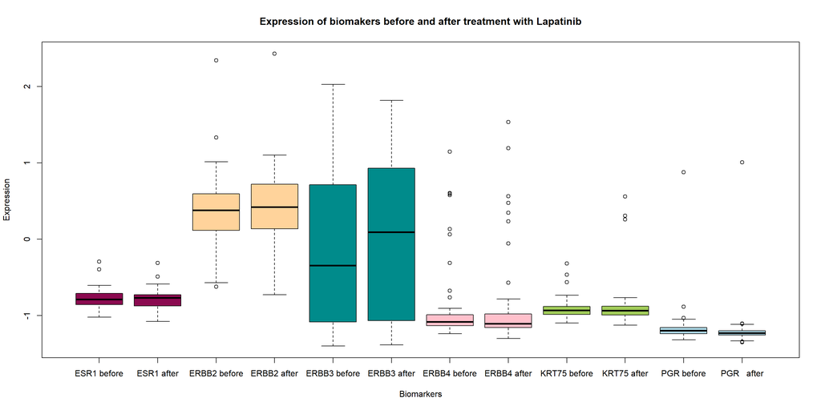

### 3.1.2 Searching for our own biomarkers

The log2FoldChange was examined from the mean of all genes before and after treatment with lapatinib.

```r
Treat<-colMeans(LapTreat, na.rm = TRUE)
Untreat<-colMeans(LapUn, na.rm = TRUE)
ut<-(Treat-Untreat)
ut_sort<-sort(ut, decreasing = TRUE)
head(ut_sort)
```

```
##     GDF15     NUPR1     DDIT3     TRIB3      ATF3      ASNS
## 0.7150148 0.6843715 0.5794749 0.5753359 0.5603209 0.5305063
```

NUPR1 stands for nuclear protein, transcriptional regulator, 1. It regulates the transcription during stress signals by empowering cells with resistance to stress.

DDIT3 encodes for the DNA damage-inducible transcript 3 protein, a member of the CCAAT/enhancer-binding protein which is a transcription factor. It is important for the response of cell stresses. The DNA damage-inducible transcript 3 protein induces cell cycle arrest and apoptosis in response to ER stress.

TRIB3 stands for Tribbles Pseudokinase 3. The kinase is induced by the transcription factor NF-kappaB. It is essential for cell proliferation.

ATF3 stands for activating transcription factor 3. It belongs to the mammalian activation transcription factor/cAMP responsive element-binding (CREB). ATF-3 is induced by physiological stress.

ASNS stands for Asparagine Synthetase: The enzyme catalyzes the production of the amino acid L-asparagine.

### 3.1.3 Boxplot of our biomarkers

[figure not shown]

```r
boxplot(LapTreat$GDF15,LapUn$GDF15,
        LapTreat$NUPR1, LapUn$NUPR1,
        LapTreat$DDIT3, LapUn$DDIT3,
        LapTreat$TRIB3, LapUn$TRIB3,
        LapTreat$ATF3,LapUn$ATF3,
        LapTreat$ASNS, LapUn$ASNS,
        col=c("deeppink4", "deeppink4", "burlywood1", "burlywood1", "darkcyan", "darkcyan", "pink", "pink", "darkolivegreen3", "darkolivegreen3", "lightblue", "lightblue"),
        names = c("GDF15 before", "GDF15 after", "NUPR1 before", "NUPR1 after ", "DDIT3 before", "DDIT3 after" ,"TRIB3 before","TRIB3 after", "ATF3 before", "ATF3 after", "ASNS before",  "ASNS after"),
        main="Expression of Biomakers before and after treatment with Lapatinib",
        xlab="Biomarkers",
        ylab="Expression")
```

```r
breastcells<-subset(Metadata, tissue == "Breast")
breast<-subset(CCLE_basalexpression, breastcells$cell  %in%  colnames(CCLE_basalexpression))
tbreastcells<-data.frame(t(breast))
breast_marker <- c(tbreastcells$GDF15,tbreastcells$NUPR1, tbreastcells$DDIT3, tbreastcells$TRIB3, tbreastcells$ATF3, tbreastcells$ASNS)
breast_marker_matrix <- data.frame(tbreastcells$GDF15,tbreastcells$NUPR1, tbreastcells$DDIT3, tbreastcells$TRIB3, tbreastcells$ATF3, tbreastcells$ASNS)
names(breast_marker_matrix)[names(breast_marker_matrix) == "tbreastcells.GDF15"] <- "GDF15"
names(breast_marker_matrix)[names(breast_marker_matrix) == "tbreastcells.NUPR1"] <- "NUPR1"
names(breast_marker_matrix)[names(breast_marker_matrix) == "tbreastcells.DDIT3"] <- "DDIT3"
names(breast_marker_matrix)[names(breast_marker_matrix) == "tbreastcells.TRIB3"] <- "TRIB3"
names(breast_marker_matrix)[names(breast_marker_matrix) == "tbreastcells.ATF3"] <- "ATF3"
names(breast_marker_matrix)[names(breast_marker_matrix) == "tbreastcells.ASNS"] <- "ASNS"
Biomarkers<-c(rep('DF15',45),rep('NUPR1',45),rep('DDIT3',45),rep('TRIB3',45),rep('ATF3',45),rep('ASNS',45))
Expression<-c(tbreastcells$GDF15,tbreastcells$NUPR1, tbreastcells$DDIT3, tbreastcells$TRIB3, tbreastcells$ATF3, tbreastcells$ASNS)
df_breast<-data.frame(Expression, Biomarkers)
```

### 3.1.4 ggBoxplot of our biomarkers’ basalexpression in breast cells with Kruskal-Wallis test

The null hypothesis is: there is no difference between the groups. The Kruskal-Wallis test is for independent samples. It tests whether the central trends of several independent samples differ.

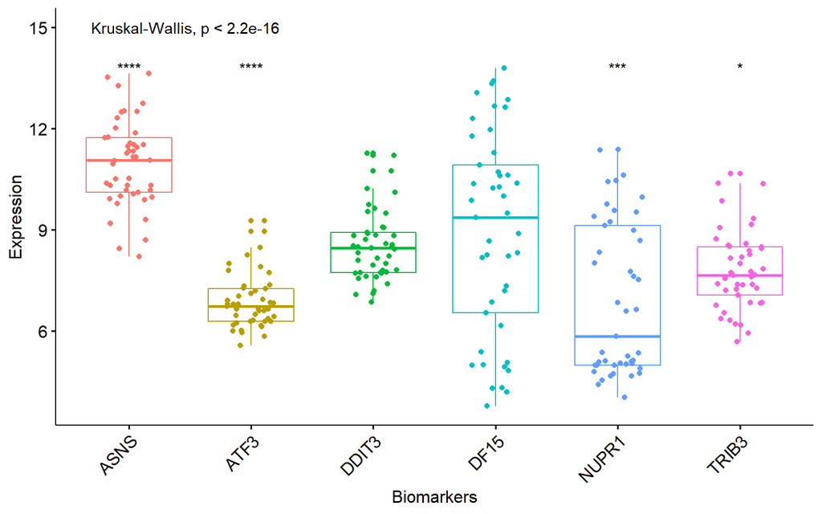

```r
ggboxplot(df_breast, x="Biomarkers", y="Expression", color = "Biomarkers",
          add = "jitter", legend = "none")+
  rotate_x_text(angle = 45)+
  stat_compare_means(method = "kruskal.test", label.y = 15)+   # Add global kurskal wallis test p-value
  stat_compare_means(label = "p.signif", method = "t.test",
                     ref.group = ".all.", hide.ns = TRUE)      # Pairwise comparison against all
```

### 3.1.5 Heatmap of biomarkers in breast cells

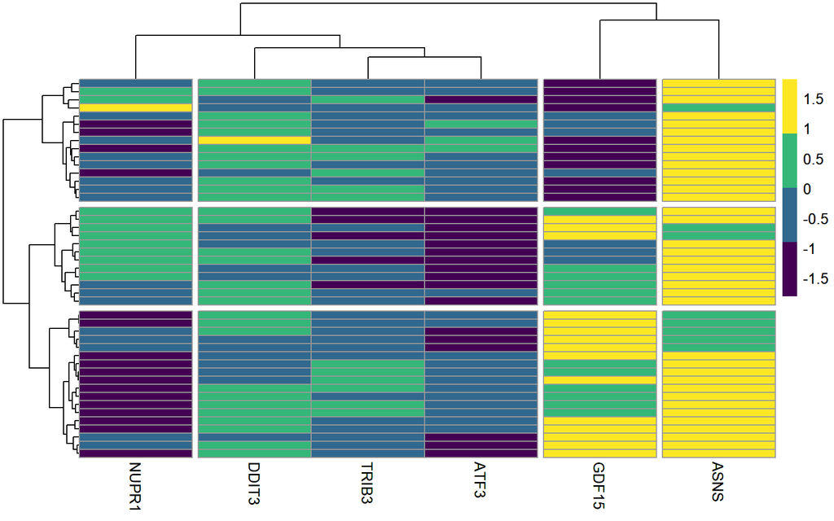

```r
pheat_breast<-pheatmap(breast_marker_matrix ,
                      show_rownames = FALSE,
                      show_colnames =TRUE,
                      cutree_cols = 4,
                      cutree_rows = 3,
                      color = viridis(4),
                      drop_levels = TRUE,
                      clustering_method = "ward.D2",
                      scale="row")
pheat_breast
```

## 3.2. Paired t-test between the Lapatinib treated und untreated data

### 3.2.1 Genome wide paired t-test

```r
t.test(before, after, paired=TRUE)
```

```
##
##  Paired t-test
##
## data:  before and after
## t = -1.5497e-13, df = 718140, p-value = 1
## alternative hypothesis: true difference in means is not equal to 0
## 95 percent confidence interval:
##  -0.0003680021  0.0003680021
## sample estimates:
## mean of the differences
##           -2.909656e-17
```

### 3.2.2 Paired t-test of our biomarker before and after treatment

The paired t-test shows a statistical significance of our biomarkers.

```r
before_biomarker<-LapUn %>% dplyr::select("GDF15", "NUPR1", "DDIT3", "TRIB3", "ATF3", "ASNS")
after_biomarker<-LapTreat %>% dplyr::select("GDF15", "NUPR1", "DDIT3", "TRIB3", "ATF3", "ASNS")
table<-data.table(col_t_paired(before_biomarker, after_biomarker, alternative = "two.sided", mu = 0,conf.level = 0.95))
Marker=c("GDF15", "NUPR1", "DDIT3", "TRIB3", "ATF3", "ASNS")
pvalue<-table$pvalue
table[, .(Marker,pvalue)]
```

```
##    Marker       pvalue
## 1:  GDF15 2.612447e-12
## 2:  NUPR1 1.327187e-11
## 3:  DDIT3 9.979311e-20
## 4:  TRIB3 6.995573e-20
## 5:   ATF3 2.142510e-12
## 6:   ASNS 2.207251e-14
```

### 3.2.3 Paired t-test over genes, increased confidence level (99 %)

```r
row_t_test<-as.data.frame(row_t_paired(before, after, alternative = "two.sided", mu = 0,conf.level = 0.99))
summary(row_t_test$pvalue)
```

```
##      Min.   1st Qu.    Median      Mean   3rd Qu.      Max.
## 0.0000000 0.0002317 0.0756336 0.2421297 0.4428285 0.9998899
```

### 3.2.4 Visualization of the genome-wide paired t-test in a vulcano plot

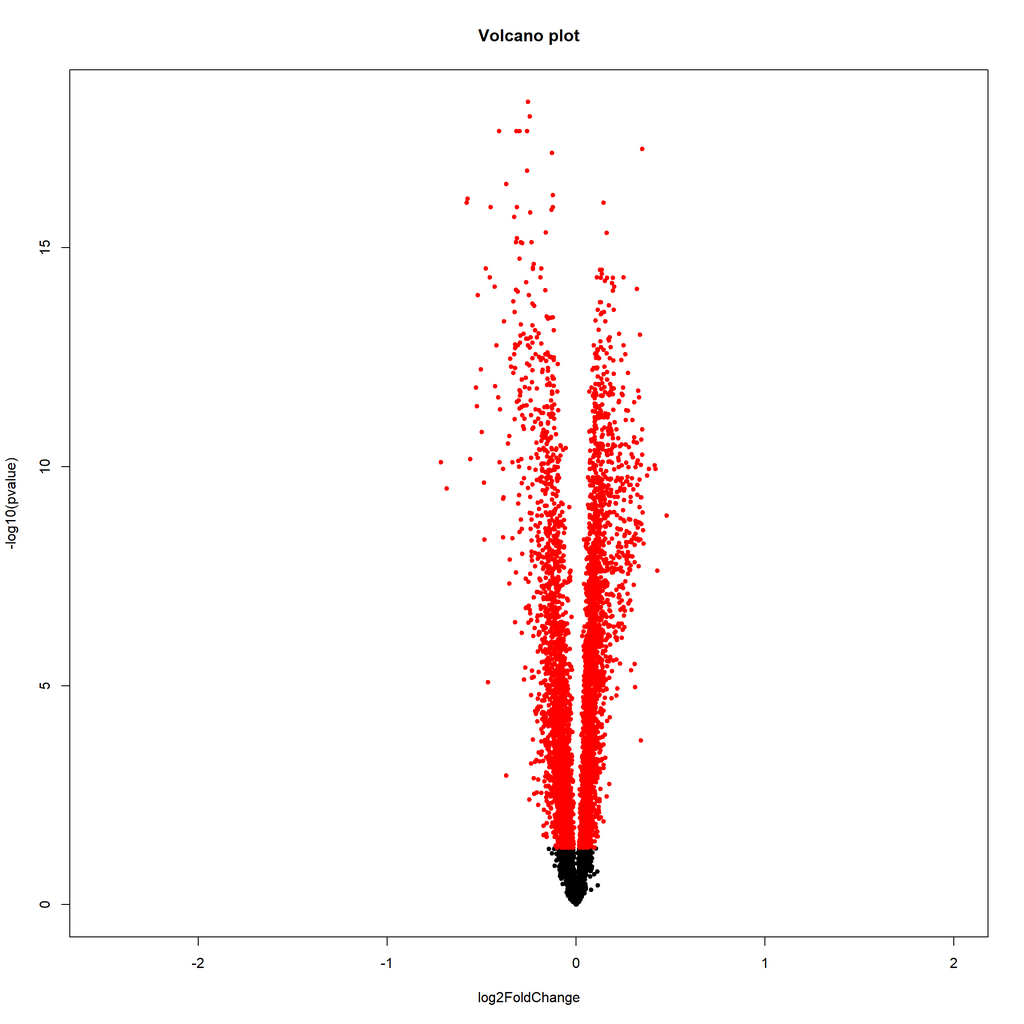

```r
Lap_t_test<-data.table(col_t_paired(LapUn, LapTreat, alternative = "two.sided", mu = 0,conf.level = 0.95))
padj<-p.adjust(Lap_t_test$pvalue, "BH")

Lapatinib_fc<-as.data.frame.numeric(colMeans(LapUn-LapTreat))
Lgenes<-(colnames(LapUn))

vulcano<-data.frame(genes=Lgenes,Fold=Lapatinib_fc, pvalue=padj)
names(vulcano)[names(vulcano) == "colMeans.LapUn...LapTreat."] <- "log2FoldChange"
with(vulcano, plot(log2FoldChange, -log10(pvalue), pch=20, main="Volcano plot", xlim=c(-2.5,2)))

# Add colored points: red if padj<0.05, blue if log2FC>1, green if both)
with(subset(vulcano, padj<.05 ), points(log2FoldChange, -log10(pvalue), pch=20, col="red"))
with(subset(vulcano, abs(log2FoldChange)>1), points(log2FoldChange, -log10(pvalue), pch=20, col="blue"))
with(subset(vulcano, padj<.05 & abs(log2FoldChange)>1), points(log2FoldChange, -log10(pvalue), pch=20, col="green"))
```

```r
# Label points with the textxy function from the calibrate plot
with(subset(vulcano, padj<.05 & abs(log2FoldChange)>1), textxy(log2FoldChange, -log10(pvalue), labs = genes, cex=.8))
```

## 3.3 K-means

```r
LapatinibFold = select(Fold_Change, contains("Lapa"))

#Determining the number of clusters
topVarFold = apply(LapatinibFold, 1, var)
summary(topVarFold)
```

```
##      Min.   1st Qu.    Median      Mean   3rd Qu.      Max.
## 0.0007514 0.0090894 0.0138573 0.0197222 0.0226351 0.4897715
```

```r
# Using the most variable, thus informative genes
topVarFold75 = LapatinibFold[topVarFold > quantile(topVarFold, probs = 0.75), ]
dim(topVarFold75)
```

```
## [1] 3325   54
```

```r
km = kmeans(x = t(topVarFold75), centers = 2, nstart = 10)
km$tot.withinss
```

```
## [1] 6627.055
```

```r
km = kmeans(x = t(topVarFold75), centers = 3, nstart = 10)
km$tot.withinss
```

```
## [1] 6159.495
```

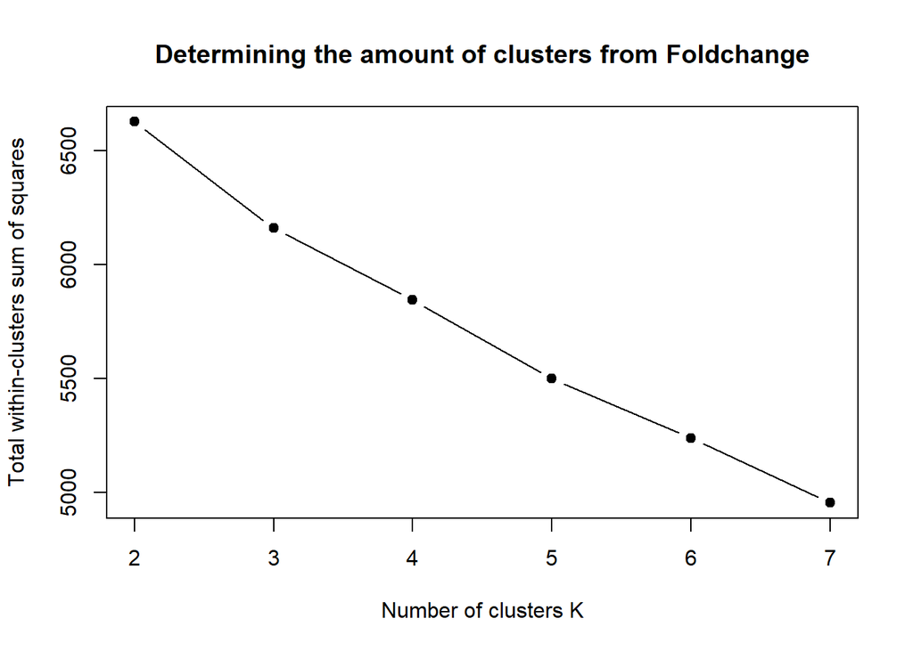

```r
#running a loop for the best n (searching for "ellbow")
wss = (sapply(2:7, function(k) {
  kmeans(x =t(topVarFold75), centers = k)$tot.withinss})  )
plot(2:7, wss, type = "b", pch = 19, xlab = "Number of clusters K", ylab = "Total within-clusters sum of squares", main = "Determining the amount of clusters from Foldchange")
```

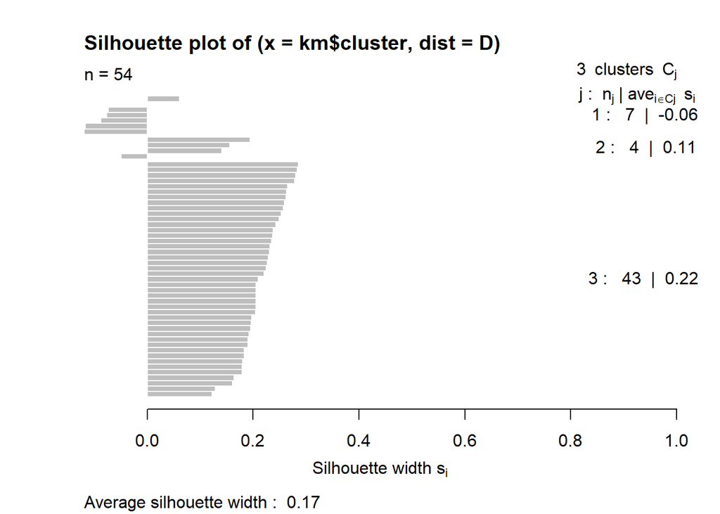

```r
# Using the silhouett method
D = dist(t(topVarFold75))
km = kmeans(x = t(topVarFold75), centers = 3, nstart = 10)
s = silhouette(km$cluster, D)
plot(s)
```

## 3.4 PCA

Since the clustering method by performing k means clustering again was not successful, we performed a principal component analysis over the selected lapatinib samples for identifying clusters or patterns while preserving as much information of the original data set as possible.

```r
L_fc <- select(Fold_Change, contains("Lapa"))

# PCA
pca <- prcomp(t(L_fc), scale = TRUE)
```

By plotting a scree plot of the variation percentage, we can display how much variation a principal component captures from the original data.

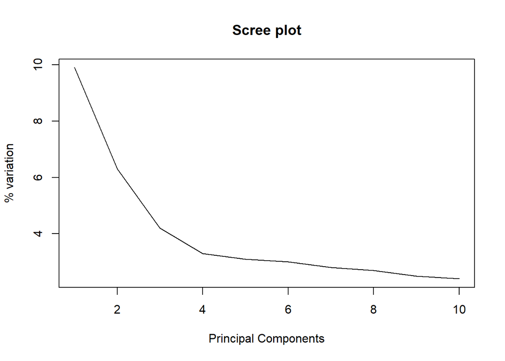

```r
pca.var <- pca$sdev^2  # sdev calculates variation each PC accounts for
pca.var.per <- round(pca.var/sum(pca.var)*100, 1)
# since percentages make more sense then normal variation values
# calculate % or variation, which is much more interesing


plot(pca.var.per[1:10], main = "Scree plot", type = "l", xlab = "Principal Components", ylab = "% variation")
```

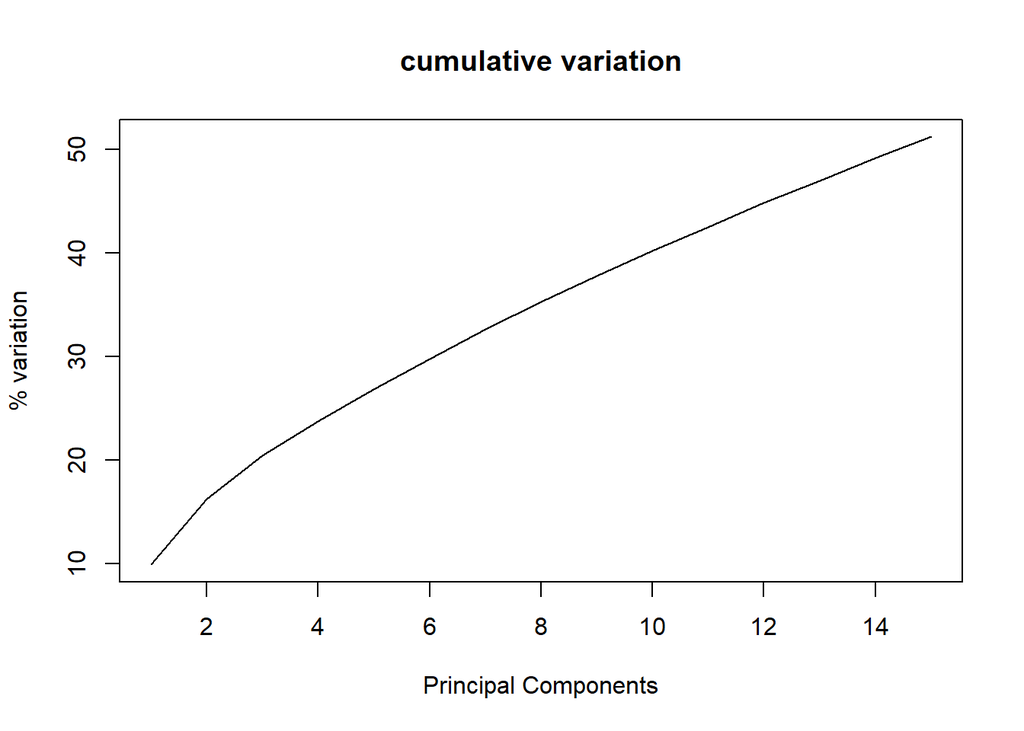

```r
plot(cumsum(pca.var.per[1:15]), main = "cumulative variation", type = "l", xlab = "Principal Components", ylab = "% variation")
```

```r
## get names of top 10 genes that contribute most to pc1
loading_scores_1 <- pca$rotation[,1]

gene_score <- abs(loading_scores_1) ## sort magnitude
gene_score_ranked <- sort(gene_score, decreasing = TRUE)

top_10_genes <- names(gene_score_ranked[1:10])
top_10_genes # show names of top 10 genes
```

```
##  [1] "MIR3658///UCK2"           "EIF2S1"
##  [3] "NOP16"                    "UCHL5"
##  [5] "HSPD1"                    "ITM2B"
##  [7] "MIR664B///SNORA56///DKC1" "KLHDC2"
##  [9] "NXT1"                     "PNO1"
```

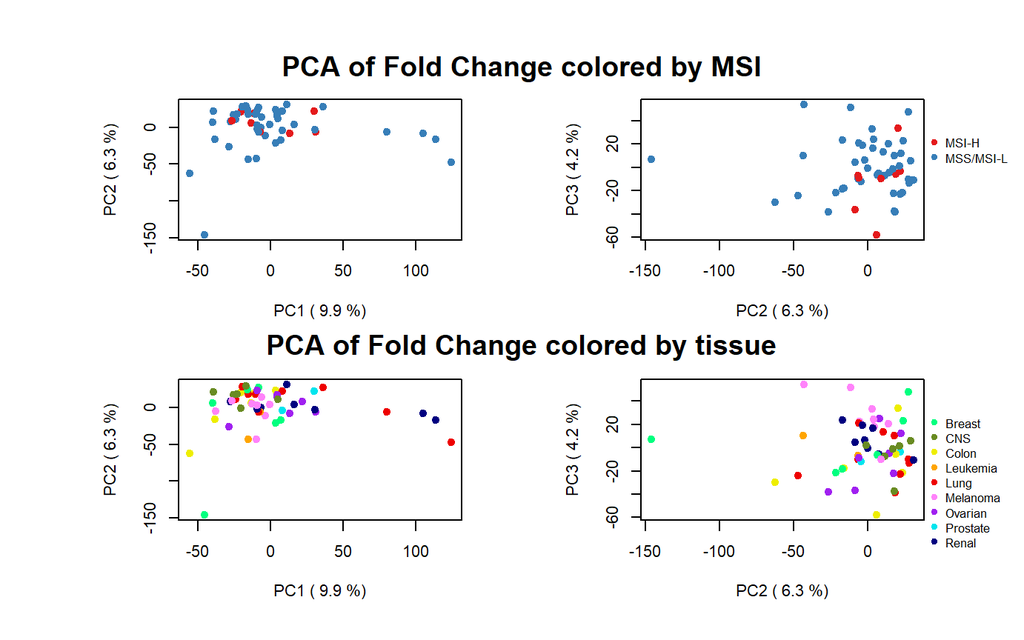

```r
par(mfrow=c(2,2), cex=0.7, oma=c(2,3,2,2))
par(mar=c(4, 6, 3, 3))
## colored by msi
#plot PC1 and PC2
msi12 <- plot(pca$x[,1],
          pca$x[,2],
          col = color_msi,
          pch = 19,
          xlab = paste("PC1 (",pca.var.per[1],"%)"),
          ylab = paste("PC2 (",pca.var.per[2],"%)"))

#create legend
legend(450, 0,
       legend = msi,
       col = colormsi,
       pch = 19,
       xpd = "FALSE",
       bty = "n",
       cex = 0.75
)
#create title
mtext("PCA of Fold Change colored by MSI",
      side = 3,
      line = -2,
      cex = 1.2,
      font = 2,
      outer = TRUE)


#plot PC2 and PC3
msi23 <- plot(pca$x[,2],
          pca$x[,3],
          col = color_msi,
          pch = 19,
          xlab = paste("PC2 (",pca.var.per[2],"%)"),
          ylab = paste("PC3 (",pca.var.per[3],"%)"))




##colored by tissue
#plot PC1 and PC2
tissue12 <- plot(pca$x[,1],
              pca$x[,2],
              col = color_tissue,
              pch = 19,
              xlab = paste("PC1 (",pca.var.per[1],"%)"),
              ylab = paste("PC2 (",pca.var.per[2],"%)"))

#create legend
legend(450, 0,
       legend = tissue,
       col = magma,
       pch = 19,
       xpd = "TRUE",
       bty = "n",
       cex = 0.75
)
#create title
mtext("PCA of Fold Change colored by tissue",
      side = 3,
      line = -16,
      cex = 1.2,
      font = 2,
      outer = TRUE)

#plot PC2 and PC3
tissue23 <- plot(pca$x[,2],
              pca$x[,3],
              col = color_tissue,
              pch = 19,
              xlab = paste("PC2 (",pca.var.per[2],"%)"),
              ylab = paste("PC3 (",pca.var.per[3],"%)"))
```

As we can see, rarely any clusters can be determined. In Addition, the colour annotation does not reveal any pattern of clustering.

## 3.5 Spearman correlation

Modelling of a linear relationship between cell doubling time and inoculation density.

```r
# Spearman correlation
cor(Cellline_Annotation$Doubling_Time, Cellline_Annotation$Inoculation_Density, method = "spearman")
```

```
## [1] 0.5674381
```

```r
plot(Cellline_Annotation$Doubling_Time, Cellline_Annotation$Inoculation_Density, pch= 16, col= "blue", main = "Spearman correlation between Doubling Time and Inoculation Density", xlab = "Doubling Time", ylab = "Inoculation Density")
lm(Cellline_Annotation$Inoculation_Density~ Cellline_Annotation$Doubling_Time)
```

```
##
## Call:
## lm(formula = Cellline_Annotation$Inoculation_Density ~ Cellline_Annotation$Doubling_Time)
##
## Coefficients:
##                       (Intercept)  Cellline_Annotation$Doubling_Time
##                            9110.9                              169.4
```

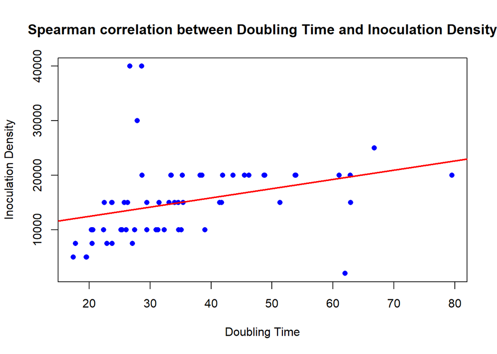

```r
abline(lm(Cellline_Annotation$Inoculation_Density ~ Cellline_Annotation$Doubling_Time), col = "red", lwd = 2)
```

As you can see from the plot, there is a positive correlation between inoculation density and doubling time. This means that the higher the inoculation density, the higher the doubling time, which suggests that the tumour grows slowly because the cells need more time to divide.